Home

# Understanding Overfitting Problem Through Simulation

### **Cheng Ximen, CFA, FRM**

If you do not wish to see the raw code please click the button below

```python
%%HTML
<button onclick="$('.input, .prompt, .output_stderr, .output_error, .output_result').toggle();">Hide Code</button>
```

## Quant Trader's Biggest Nightmare

I guess most quant traders had similar experience like this. We developed a trading algorithm, fine tuned the parameters on the training dataset and backtested on the testing dataset. Just when we are ready to open a champagne to celebrate, the algo failed miserably during live trading. It's like a nightmare always linger at the back of the mind of every quant trader. Part of it is because the dataset which we are fitting is inherently unstationary. There're times new conditions and factors arises that causes the distributions of our dataset to change dramatically, rendering the past patterns we found no longer revelent. I agree we should always have a safety mechanism in our investment system to deal with the tail risk. Black swan event happens a lot frequent than we expected. However most of the time even when nothing extraordinary happens, the algorithm we developed still fails. That's when we have to admit that we are probably overfitting the dataset. If we are in a situation that, no matter what we do there's a chance that the algorthm we developed is just not going to work, then the natural question is what's the likelyhood of this situation, just like when someone is going to defuse a bomb, he will definitely want to know what's the probability the it's going to blow up no matter what he does. I believe simulation can be a great way for us to gain a better understanding of the problem.

## Let's Simulate

```python
import pandas as pd
import numpy as np
import seaborn as sns
import matplotlib.pyplot as plt
%matplotlib inline
import warnings
warnings.filterwarnings('ignore')
import pymc3 as pm
import pomegranate as pome
import statsmodels.api as sm
```

Say we want to develop a market timing strategy on a specific market index. I used [CSI300](https://en.wikipedia.org/wiki/CSI_300_Index) in this research but the methodology used can be used in all asset classes. Firstly let's get a sense of what the data looks like.

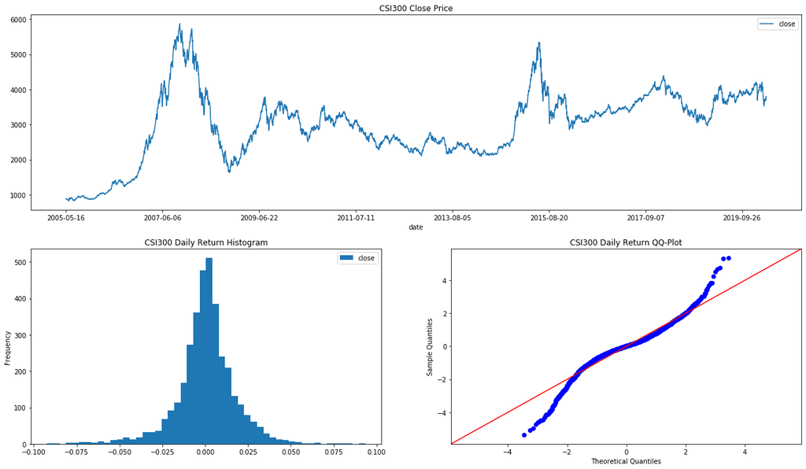

```python
price = pd.read_csv('price.csv',index_col=0,names=['date','close'])
daily_return = price.pct_change(1).dropna()
# plot chart
fig = plt.figure(figsize=(21,12))
ax1 = fig.add_subplot(211)
ax2 = fig.add_subplot(223)
ax3 = fig.add_subplot(224)
price.plot(ax = ax1,title = 'CSI300 Close Price')
daily_return.plot(kind='hist',bins=50,ax=ax2,title='CSI300 Daily Return Histogram')
sm.qqplot(daily_return.iloc[:,0],ax=ax3,fit=True,line='45')
ax3.set_title('CSI300 Daily Return QQ-Plot')
plt.show()
```

It doesn't look like a healthy market where we can be rest assured to bet our savings. But for this experiment, it looks like the perfect dataset. The daily return is roughly bell shaped curve centered around zero with fat tail like all typical financial data series. Now let's design a bunch of random market timing strategies on this price series and see what what is the distribution of it's sharp ratio looks like, so that we can see if we designed a system that achieved a sharp ratio of one, what's the likelyhood that it's a random strategy got lucky. I'll assume we are developing long only strategy for the sake of simplicity. The probability that that we will hold long position every day comes from a uniform distribution between 0 to 100%. If we repeat repeat the simulation process enough times we'll get a distribution.

```python
# number of random strategy trials
n_trial = 500
# set up a probability model
with pm.Model() as model:
    p = pm.distributions.continuous.Uniform('p',lower=0, upper=1)
    hold = pm.distributions.discrete.Bernoulli('hold',p)
    trace = pm.sample(n_trial*len(daily_return), tune=1000, cores=-1)
```

```
Sequential sampling (2 chains in 1 job)
CompoundStep
>NUTS: [p]
>BinaryGibbsMetropolis: [hold]
```

```python
# create daily return samples
holding_status_samples = trace['hold']
holding_status_samples = holding_status_samples.reshape((len(daily_return),-1))
samples_return = holding_status_samples*daily_return.values
```

Now we have created 1000 samples of returns from random strategy. let's select 10 samples and compare it to buy and hold strategy to see what it looks like. The red line represents what our NAV will look like if we just do buy and hold. Blue lines represent random strategies.

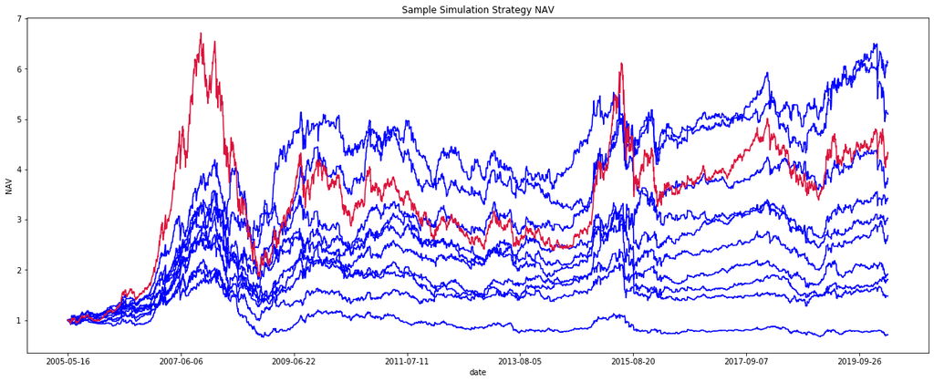

```python
# add origional index return to sample dataset
plot_samples = np.hstack((samples_return[:,-10:],daily_return))+1
# calculate cumulative NAV
plot_samples = np.insert(plot_samples,0,np.ones(11),0)
plot_samples = np.cumprod(plot_samples,axis=0)
plot_samples = pd.DataFrame(plot_samples,index=price.index)

fig,ax = plt.subplots(figsize=(21,8))
for c in range(plot_samples.shape[1]):
    if c == 10:
        plot_samples.iloc[:,c].plot(ax=ax,color='crimson')
    else:
        plot_samples.iloc[:,c].plot(ax=ax,color='blue')
ax.set_title('Sample Simulation Strategy NAV')
ax.set_ylabel('NAV')
plt.show()
```

By just randomly selecting 10 samples we already spoted two works better than simple buy and hold strategy. but all the blue lines represent NAV from random strategy. Now let's calculate the sharp ratio for all the 1000 random strategy samples to see what does the distribution looks like.

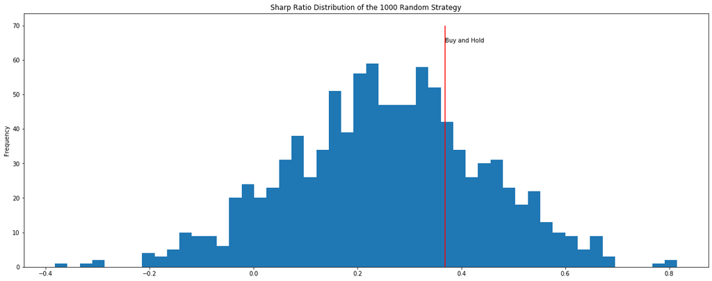

```python
def sharp_cal(daily_re):
    daily_re = daily_re.ravel()
    # calculate cumulative return
    cum_re = np.cumprod(np.insert(daily_re+1,0,1))
    # geometric average of return
    avg_re = cum_re[-1]**(1/len(daily_re))-1
    # calculate daily standard deviation of return
    avg_std = daily_re.std()
    return avg_re/avg_std*(250**0.5)

# calculate sharp ratio for all sample strategies
samples_sharp = np.apply_along_axis(sharp_cal,0,samples_return)
# plot sharp ratio distribution chart
ax = pd.Series(samples_sharp).plot(kind='hist',figsize=(21,8),bins=50, title='Sharp Ratio Distribution of the 1000 Random Strategy')
ax.vlines(sharp_cal(daily_return.values),0,70,color='red')
ax.text(sharp_cal(daily_return.values),65,'Buy and Hold',)
plt.show()
```

The red line is where the sharp ratio of basic buy and hold strategy is at. Among our 1000 random strategies, there're 268 beat the index. If we use the buy and hold strategy as the base to determine whether our strategy is contains true alpha, we probably will fail miserably in real life. It also proves that at least for this index, if we do not know what we are doing, we are more likely to fare better just holding the index instead of trying to trade in and out. Based on the 1000 samples we have drawn, to reduce the probability that our strategy is a dumb random strategy to less than 5%, the sharp ratio of our strategy have to be at least 0.55, which is 1.5 times of the sharp ratio of simple buy and hold strategy. (With more simulation samples the threshold point can be more reliable or you can also do a KDE to deduce the underlying distribution.)

## The Evil of Multi-Testing

Does it mean we are save to say we found something valuble if we developed an algorithm with over 0.6 sharp ratio in this dataset? That's shouldn't be too hard. With enough effort we probably can find something better. But a lot of the time we still found the algorithm is not doing as good as we expected. That probably is due to multi-testing. This is such an important concept that I think every quant should keep it at the back of our head when doing research. It basiclly means that everytime we tried something that does not work and we will remove them from our choices of algorithim develping (sample selection). That increases our chances to select good performing random strategies. It is also called selection bias. Let's run a simple simulation it will become much clearer.

Say we tested a few strategies and ruled out about 50% of sample random strategies with sharp less than 0.3 in the next phase of development of trading strategy. In that case the random strategy distribution we are facing varies dramatically from the true distribution ploted above.

```python
# set a a binomial distribution sample generator
d_bi = pome.distributions.DiscreteDistribution({1:0.5,0:0.5})
# draw samples
rule_out_status = d_bi.sample(len(samples_sharp[samples_sharp<0.3]))
# create a mask with the same size of samples
rule_out_mask = np.insert(rule_out_status,len(rule_out_status),np.zeros(len(samples_sharp)-len(rule_out_status)))
# create new samples
new_samples_sharp = np.sort(samples_sharp)[np.logical_not(rule_out_mask)]
```

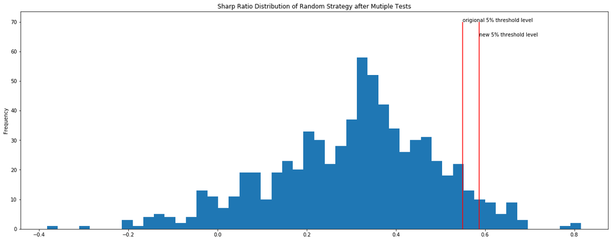

```python
# plot sharp ratio distribution chart
ax = pd.Series(new_samples_sharp).plot(kind='hist',figsize=(21,8),bins=50, title='Sharp Ratio Distribution of Random Strategy after Mutiple Tests')
ax.vlines(0.55,0,70,color='red')
ax.text(0.55,70,'origional 5% threshold level')
ax.vlines(new_samples_sharp[-round(len(new_samples_sharp)*0.05)],0,70,color='red')
ax.text(new_samples_sharp[-round(len(new_samples_sharp)*0.05)],65,'new 5% threshold level')
plt.show()
```

As you can see the more we try, the less chance we have in encountering bad performing random strategies, which pushes true 5% threshold level further to the right, meaning the more we try, the higher sharp ratio we need to achieve to be save from the possibility that it is a random strategy. There are a lot of academic papers on this topic. This is just my way of understanding the mechanics behind muti-testing problem and how to make sense of [Bonferroni Correction](https://mathworld.wolfram.com/BonferroniCorrection.html).

## How Does It Relate to Our Day to Day Research Practice

In short, let's be super aware of overfitting risk and incorporate measures to mitigate. Below is some general suggestions from Marcos Lopez de Prado I borrowed "quote unquote", as I believe I couldn't have said it any better. There're a lot of great techniques in his paper that we can use in our research process as well. I really learned a lot. The excerpts Below is from his paper at [here](https://papers.ssrn.com/sol3/papers.cfm?abstract_id=3257497).

> 1. **Develop models for entire asset classes** or investment universes, rather than for specific securities. Investors diversify, hence they do not make mistake X only on security Y. If you find mistake X only on security Y, no matter how apparently profitable, it is likely a false discovery.
> 2. **Apply bagging** as a means to both prevent overfitting and reduce the variance of the forecasting error. If bagging deteriorates the performance of a strategy, it was likely overfit to a small number of observations or outliers.
> 3. **Do not backtest until all your research is complete**
> 4. **Record every backtest conducted on a dataset** so that the probability of backtest overfitting may be estimated on the final selected result, and the Sharpe ratio may be properly deflated by the number of trials carried out (Bailey and López de Prado [2014b]).
> 5. **Simulate scenarios rather than history**. A standard backtest is a historical simulation, which can be easily overfit. History is just the random path that was realized, and it could have been entirely different. Your strategy should be profitable under a wide range of scenarios, not just the anecdotal historical path. It is harder to overfit the outcome of thousands of “what if” scenarios.
> 6. **Do not research under the influence of a backtest**. If the backtest fails to identify a profitable strategy, start from scratch. Resist the temptation of reusing those results.